# JSON Vignette

Yinzhou Zhu 5/31/2020

- About JSON data
- Packages for reading JSON
- JSON example: NHL API
- Formatted data
- References

## About JSON data

**JavaScript** is the most widely used language that powers interactions between client devices and server/web applications, where it allows programmers to implement complex features<sup>1</sup>. As a high-level language, it is also light-weight<sup>2</sup>.  
JavaScript Object Notation (**JSON**), as its name also implies, is a type of data that is easily converted from and to **JavaScript** objects<sup>3</sup>. **JSON** is stored as text string, which makes it possible to store **JavaScript** objects as text. It is now a very standard way for data communication over the network, which used to be primarily with **XML** format that is much heavier in weight.  
As described, **JSON** was built with purpose of being a standardized transfer language that is easy for human to read and at the same time easy for machine to parse and execute <sup>4</sup>.  
The flexibility of **JSON** means it’s also suitable for general data transfer beyond **JavaScript** objects between devices across the web. This makes it a popular way for accessing data through cloud where **JSON API** is implemented<sup>5</sup>.

## Packages for reading JSON

### `rjson`, `jsonlite`, `RJSONIO` and `tidyjson`

`rjson`, `jsonlite` and `RJSONIO` are 3 popular R packages used for working with **JSON** data. Functionality wise, they are all very similar, where they allow conversion of **R** objects from and to **JSON** data. The major differences being mainly: usage syntax, internal implementation methods (such as how data is read etc., thus affecting speed) and extended features. For example, `jsonlite` is able to stream to/from JSON file if the data that we are dealing with is large, which could be an advantage<sup>6</sup>. `tidyjson` on the other hand seems to be gaining traction. Under the same framework of `tidyverse`, this package could be particularly useful in streamlining our pipeline when appropriate<sup>7</sup>.

### Why choosing `jsonlite`?

I have chosen to work with `jsonlite` for the following reasons:  
* I have gotten most familiar with this package due to course usage.  
* It has advantage and flexibility for dealing with a large amount of data as mentioned above.  
* The overall consensus I got from reading online is that `jsonlite` strikes a very good balance between features and performance and is particulate in format conversions.

## JSON example: NHL API

```r
api_url <- 'https://records.nhl.com/site/api'
nhl_franchise <- function() {
  franchises <- httr::GET(paste0(api_url, '/franchise'))
  franchises <- httr::content(franchises, 'text')
  franchises <- fromJSON(franchises, flatten = TRUE)
}
nhl_franchise_team_totals <- function() {
  franchises <- httr::GET(paste0(api_url, '/franchise-team-totals'))
  franchises <- httr::content(franchises, 'text')
  franchises <- fromJSON(franchises, flatten = TRUE)
}
nhl_franchise_records <- function(franchise_id, records = 'season') {
  if (!records %in% c('season', 'goalie', 'skater')) {
    stop("Records can only be 'season', 'goalie' or 'skater'.")
  }
  if (is.na(as.numeric(franchise_id))) {
    stop("Please enter a valid franchasie ID.")
  }
  if (records == 'season') {
    franchises <- httr::GET(paste0(api_url, '/franchise-season-records?cayenneExp=franchiseId=', franchise_id))
  } else if (records == 'goalie') {
    franchises <- httr::GET(paste0(api_url, '/franchise-goalie-records?cayenneExp=franchiseId=', franchise_id))
  } else {
    franchises <- httr::GET(paste0(api_url, '/franchise-skater-records?cayenneExp=franchiseId=', franchise_id))
  }
  franchises <- httr::content(franchises, 'text')
  franchises <- fromJSON(franchises, flatten = TRUE)
}
```

## Formatted data

### List of all franchises.

```r
nhl_franchise()$data %>% kable(caption = "Display of the entire content of list of all franchises.")
```

| id | firstSeasonId | lastSeasonId | mostRecentTeamId | teamCommonName | teamPlaceName |
| --- | --- | --- | --- | --- | --- |
| 1 | 19171918 | NA | 8 | Canadiens | Montréal |
| 2 | 19171918 | 19171918 | 41 | Wanderers | Montreal |
| 3 | 19171918 | 19341935 | 45 | Eagles | St. Louis |
| 4 | 19191920 | 19241925 | 37 | Tigers | Hamilton |
| 5 | 19171918 | NA | 10 | Maple Leafs | Toronto |
| 6 | 19241925 | NA | 6 | Bruins | Boston |
| 7 | 19241925 | 19371938 | 43 | Maroons | Montreal |
| 8 | 19251926 | 19411942 | 51 | Americans | Brooklyn |
| 9 | 19251926 | 19301931 | 39 | Quakers | Philadelphia |
| 10 | 19261927 | NA | 3 | Rangers | New York |
| 11 | 19261927 | NA | 16 | Blackhawks | Chicago |
| 12 | 19261927 | NA | 17 | Red Wings | Detroit |
| 13 | 19671968 | 19771978 | 49 | Barons | Cleveland |
| 14 | 19671968 | NA | 26 | Kings | Los Angeles |
| 15 | 19671968 | NA | 25 | Stars | Dallas |
| 16 | 19671968 | NA | 4 | Flyers | Philadelphia |
| 17 | 19671968 | NA | 5 | Penguins | Pittsburgh |
| 18 | 19671968 | NA | 19 | Blues | St. Louis |
| 19 | 19701971 | NA | 7 | Sabres | Buffalo |
| 20 | 19701971 | NA | 23 | Canucks | Vancouver |
| 21 | 19721973 | NA | 20 | Flames | Calgary |
| 22 | 19721973 | NA | 2 | Islanders | New York |
| 23 | 19741975 | NA | 1 | Devils | New Jersey |
| 24 | 19741975 | NA | 15 | Capitals | Washington |
| 25 | 19791980 | NA | 22 | Oilers | Edmonton |
| 26 | 19791980 | NA | 12 | Hurricanes | Carolina |
| 27 | 19791980 | NA | 21 | Avalanche | Colorado |
| 28 | 19791980 | NA | 53 | Coyotes | Arizona |
| 29 | 19911992 | NA | 28 | Sharks | San Jose |
| 30 | 19921993 | NA | 9 | Senators | Ottawa |
| 31 | 19921993 | NA | 14 | Lightning | Tampa Bay |
| 32 | 19931994 | NA | 24 | Ducks | Anaheim |
| 33 | 19931994 | NA | 13 | Panthers | Florida |
| 34 | 19981999 | NA | 18 | Predators | Nashville |
| 35 | 19992000 | NA | 52 | Jets | Winnipeg |
| 36 | 20002001 | NA | 29 | Blue Jackets | Columbus |
| 37 | 20002001 | NA | 30 | Wild | Minnesota |
| 38 | 20172018 | NA | 54 | Golden Knights | Vegas |

Display of the entire content of list of all franchises.

### Basic overview for New York Rangers and Boston Bruins.

There seems to be more than one game type, I summarized each here.

```r
totals <- nhl_franchise_team_totals()
nyr_bb_seasons <- totals$data %>%
  filter(franchiseId == 6 | franchiseId == 10) %>%
  select(franchiseId, gamesPlayed, wins, gameTypeId)
nyr_bb_games_2 <- nyr_bb_seasons %>%
  group_by(franchiseId) %>%
  filter(gameTypeId == 2) %>%
  summarise(games_played = sum(gamesPlayed), wins = sum(wins))
nyr_bb_games_3 <- nyr_bb_seasons %>%
  group_by(franchiseId) %>%
  filter(gameTypeId == 3) %>%
  summarise(games_played = sum(gamesPlayed), wins = sum(wins))
nyr_bb_games_2 <- nyr_bb_games_2 %>% mutate(win_ratio = wins / games_played)
nyr_bb_games_3 <- nyr_bb_games_3 %>% mutate(win_ratio = wins / games_played)
nyr_bb_games_2$wins <- NULL
nyr_bb_games_3$wins <- NULL
rownames(nyr_bb_games_2) <- c('New York Rangers', 'Boston Ruins')
colnames(nyr_bb_games_2) <- c('Franchise ID', 'Games Played', 'Win Ratio', 'Game Type ID')
rownames(nyr_bb_games_3) <- c('New York Rangers', 'Boston Ruins')
colnames(nyr_bb_games_3) <- c('Franchise ID', 'Games Played', 'Win Ratio', 'Game Type ID')

kable(nyr_bb_games_2, caption = 'Win ratio stats for Game Type 2')
```

[output not shown]

Win ratio stats for Game Type 2

```r
kable(nyr_bb_games_3, caption = 'Win ratio stats for Game Type 3')
```

[output not shown]

Win ratio stats for Game Type 3

### Whats the relationship between penalty minutes and wins ratio?

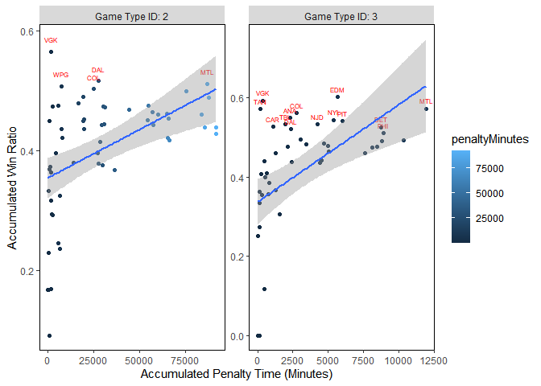

```r
selected_columns <- totals$data %>%
  group_by(gameTypeId) %>%
  select(triCode, firstSeasonId, gamesPlayed, gameTypeId, penaltyMinutes, wins) %>%
  mutate(win_ratio = wins / gamesPlayed, .keep = 'unused')
selected_columns <- selected_columns %>%
  mutate(game_type = paste0('Game Type ID: ', gameTypeId), .keep = 'unused') %>%
  mutate(era = if_else(firstSeasonId <= 19911992, 'Pre-Modern', 'Modern'), .keep = 'unused')
scatter_plot <- selected_columns %>% ggplot(aes(penaltyMinutes, win_ratio)) +
  geom_point(aes(color = penaltyMinutes)) +
  facet_wrap(vars(game_type), scales = "free") +
  xlab('Accumulated Penalty Time (Minutes)') +
  ylab('Accumulated Win Ratio') +
  geom_text(aes(label = triCode), color = "red", data = subset(selected_columns, win_ratio > 0.5), size = 2, nudge_y = 0.02) +
  theme(panel.background = element_rect(fill = 'transparent', color = 'black'), panel.grid = element_blank())
scatter_plot + geom_smooth(method = lm)
```

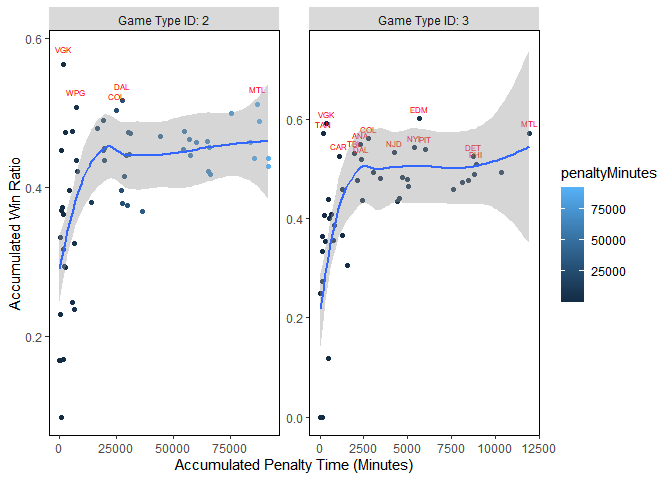

```r
scatter_plot + geom_smooth()
```

### Are there performance differences between teams joint before 1991 and after 1991?

[figure not shown]

```r
bar_plot <- selected_columns %>% ggplot(aes(era)) +
  geom_bar(aes(era)) +
  geom_bar(aes(fill = era), data = subset(selected_columns, win_ratio > 0.4)) +
  facet_wrap(vars(game_type), scales = "free") +
  xlab("Era (Teams Joint Before/After 1991)") +
  ylab("Number of Teams")
bar_plot +
  theme(panel.background = element_rect(fill = 'transparent', color = 'black'), panel.grid = element_blank()) +
  scale_fill_discrete(name = "Category", labels = c("Modern: Win Ratio > 0.3", "Pre-Modern: Win Ratio > 0.3"))
```

### Is road-win-loss indicative of total win ratio? Team tiers were set artificially based on win ratios (no other factors were considered).

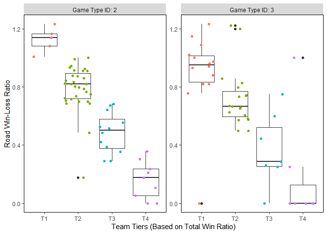

```r
selected_columns <- totals$data %>%
  group_by(gameTypeId) %>%
  select(gamesPlayed, gameTypeId, triCode, roadLosses, roadWins, gameTypeId, wins) %>%
  mutate(win_ratio = wins / gamesPlayed, .keep = 'unused') %>%
  mutate(category_col = if_else(win_ratio < 0.3, 'T4', if_else(win_ratio >= 0.3 & win_ratio < 0.4, 'T3', if_else(win_ratio >= 0.4 & win_ratio < 0.5, 'T2', if_else(win_ratio > 0.5, 'T1', 'NA')))))
selected_columns <- selected_columns %>%
  mutate(game_type = paste0('Game Type ID: ', gameTypeId), .keep = 'unused') %>%
  mutate(road_win_loss_ratio = roadWins / roadLosses, .keep = 'unused')
box_plot <- selected_columns %>% ggplot(aes(category_col, road_win_loss_ratio)) +
  geom_boxplot() +
  geom_jitter(aes(color = category_col)) +
  facet_wrap(vars(game_type), scales = 'free') +
  xlab("Team Tiers (Based on Total Win Ratio)") +
  ylab("Road Win-Loss Ratio")
box_plot + theme(panel.background = element_rect(fill = 'transparent', color = 'black'), panel.grid = element_blank(), legend.position = "none")
```

## References

**1.** https://www.bigcommerce.com/ecommerce-answers/what-javascript-and-why-it-important/  
**2.** https://developer.mozilla.org/en-US/docs/Web/JavaScript  
**3.** https://www.w3schools.com/js/js_json_intro.asp  
**4.** https://www.json.org/json-en.html  
**5.** https://nordicapis.com/the-benefits-of-using-json-api/  
**6.** http://anotherpeak.org/blog/tech/2016/03/10/understand_json_3.html  
**7.** https://cran.csiro.au/web/packages/tidyjson/vignettes/introduction-to-tidyjson.html